# Travel Package Purchase Prediction

## Customer Profile by Product Type

```python
cust_prof=df_tour[df_tour['ProdTaken']==1]
```

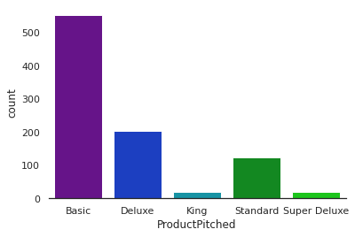

```python
#plt.figure(figsize= [12,12])

sns.countplot(x="ProductPitched", data=cust_prof)
sns.despine(top=True,right=True,left=True) # to remove side line from graph
```

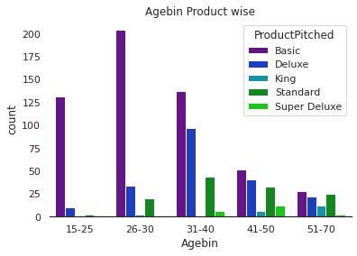

```python
sns.countplot(x='Agebin',hue='ProductPitched',data=cust_prof).set_title('Agebin Product wise')
#sns.catplot(x='Agebin',hue='ProductPitched',col='ProdTaken',data=df_tour,kind='count')
sns.despine(top=True,right=True,left=True) # to remove side line from graph
```

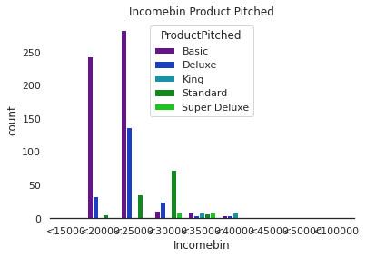

```python
sns.countplot(x='Incomebin',hue='ProductPitched',data=cust_prof).set_title('Incomebin Product Pitched')
#sns.catplot(x='Incomebin',hue='ProductPitched',col='ProdTaken',data=df_tour,kind='count',aspect=1.5)
sns.despine(top=True,right=True,left=True) # to remove side line from graph
```

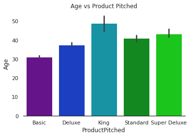

```python
sns.barplot(y='Age',x='ProductPitched',data=cust_prof).set_title('Age vs Product Pitched')
#sns.catplot(y='Age',x='ProductPitched',col='ProdTaken',data=df_tour,kind='bar',aspect=1.5)
sns.despine(top=True,right=True,left=True) # to remove side line from graph
```

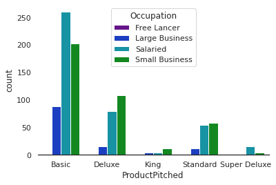

```python
sns.countplot(x="ProductPitched", data=cust_prof,  hue="Occupation")
#sns.catplot(hue='Occupation',x='ProductPitched',col='ProdTaken',data=df_tour,kind='count',aspect=1.5)
sns.despine(top=True,right=True,left=True) # to remove side line from graph
```

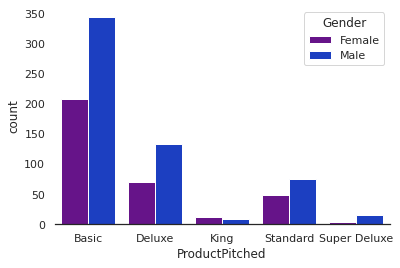

```python
#sns.catplot(hue='Gender',x='ProductPitched',col='ProdTaken',data=df_tour,kind='count',aspect=1.5)
sns.countplot(x="ProductPitched", data=cust_prof,  hue="Gender")
sns.despine(top=True,right=True,left=True) # to remove side line from graph
```

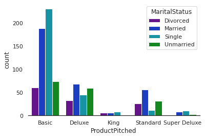

```python
sns.countplot(x="ProductPitched", data=cust_prof,  hue="MaritalStatus")
sns.despine(top=True,right=True,left=True) # to remove side line from graph
```

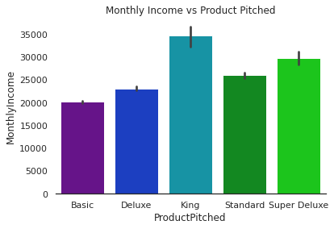

```python
sns.barplot(y='MonthlyIncome',x='ProductPitched',data=cust_prof).set_title('Monthly Income vs Product Pitched')
sns.despine(top=True,right=True,left=True) # to remove side line from graph
```

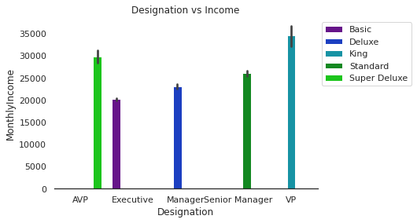

```python
sns.barplot(x='Designation',y='MonthlyIncome',data=cust_prof,hue='ProductPitched').set_title('Designation vs Income')
sns.despine(top=True,right=True,left=True) # to remove side line from graph
plt.legend(bbox_to_anchor=(1, 1))
```

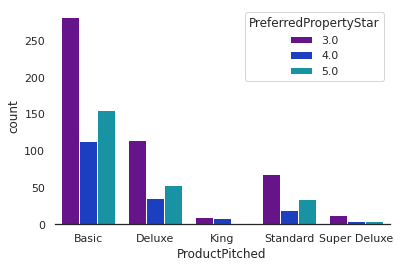

```python
sns.countplot(x="ProductPitched", data=cust_prof,  hue="PreferredPropertyStar")
sns.despine(top=True,right=True,left=True) # to remove side line from graph
```

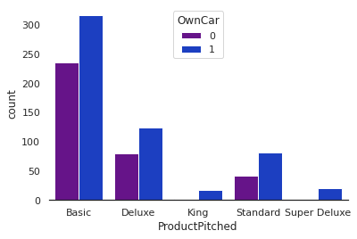

```python
sns.countplot(x="ProductPitched", data=cust_prof,  hue="OwnCar")
sns.despine(top=True,right=True,left=True) # to remove side line from graph
```

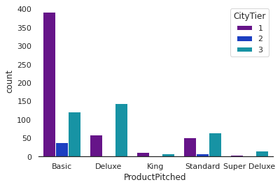

```python
sns.countplot(x="ProductPitched", data=cust_prof,  hue="CityTier")
sns.despine(top=True,right=True,left=True) # to remove side line from graph
```

```python
cust_prof.groupby(['ProductPitched']).agg({'MonthlyIncome':{'mean','min','max'},'Age':{'mean','min','max'}})
```

| ProductPitched | MonthlyIncome min | MonthlyIncome max | MonthlyIncome mean | Age min | Age max | Age mean |
| --- | --- | --- | --- | --- | --- | --- |
| Basic | 16009.00000 | 37868.00000 | 20179.10870 | 18.00000 | 59.00000 | 31.26449 |
| Deluxe | 17086.00000 | 38525.00000 | 23093.33333 | 21.00000 | 59.00000 | 37.59069 |
| King | 17517.00000 | 38537.00000 | 34672.10000 | 27.00000 | 59.00000 | 48.90000 |
| Standard | 17372.00000 | 38395.00000 | 26035.41935 | 19.00000 | 60.00000 | 40.99194 |
| Super Deluxe | 21151.00000 | 37502.00000 | 29823.80000 | 39.00000 | 56.00000 | 43.50000 |

```python
cust_prof[cust_prof['ProductPitched']=='Basic'].describe(include='all').T
```

|  | count | unique | top | freq | mean | std | min | 25% | 50% | 75% | max |
| --- | --- | --- | --- | --- | --- | --- | --- | --- | --- | --- | --- |
| ProdTaken | 552.0 | 1.0 | 1.0 | 552.0 | NaN | NaN | NaN | NaN | NaN | NaN | NaN |
| Age | 552.0 | NaN | NaN | NaN | 31.26449 | 8.7659 | 18.0 | 26.0 | 30.0 | 34.0 | 59.0 |
| TypeofContact | 552 | 2 | Self Enquiry | 358 | NaN | NaN | NaN | NaN | NaN | NaN | NaN |
| CityTier | 552.0 | 3.0 | 1.0 | 392.0 | NaN | NaN | NaN | NaN | NaN | NaN | NaN |
| DurationOfPitch | 552.0 | NaN | NaN | NaN | 15.69293 | 7.78024 | 6.0 | 9.0 | 14.0 | 21.0 | 36.0 |
| Occupation | 552 | 4 | Salaried | 260 | NaN | NaN | NaN | NaN | NaN | NaN | NaN |
| Gender | 552 | 2 | Male | 344 | NaN | NaN | NaN | NaN | NaN | NaN | NaN |
| NumberOfPersonVisiting | 552.0 | NaN | NaN | NaN | 2.9058 | 0.70144 | 2.0 | 2.0 | 3.0 | 3.0 | 4.0 |
| NumberOfFollowups | 552.0 | NaN | NaN | NaN | 3.95109 | 0.96366 | 1.0 | 3.0 | 4.0 | 5.0 | 6.0 |
| ProductPitched | 552 | 1 | Basic | 552 | NaN | NaN | NaN | NaN | NaN | NaN | NaN |
| PreferredPropertyStar | 552.0 | NaN | NaN | NaN | 3.77174 | 0.86181 | 3.0 | 3.0 | 3.0 | 5.0 | 5.0 |
| MaritalStatus | 552 | 4 | Single | 230 | NaN | NaN | NaN | NaN | NaN | NaN | NaN |
| NumberOfTrips | 552.0 | NaN | NaN | NaN | 3.22101 | 2.07353 | 1.0 | 2.0 | 3.0 | 3.25 | 20.0 |
| Passport | 552.0 | 2.0 | 1.0 | 322.0 | NaN | NaN | NaN | NaN | NaN | NaN | NaN |
| PitchSatisfactionScore | 552.0 | NaN | NaN | NaN | 3.21377 | 1.35307 | 1.0 | 2.0 | 3.0 | 4.0 | 5.0 |
| OwnCar | 552.0 | 2.0 | 1.0 | 316.0 | NaN | NaN | NaN | NaN | NaN | NaN | NaN |
| NumberOfChildrenVisiting | 552.0 | NaN | NaN | NaN | 1.2192 | 0.86731 | 0.0 | 1.0 | 1.0 | 2.0 | 3.0 |
| Designation | 552 | 1 | Executive | 552 | NaN | NaN | NaN | NaN | NaN | NaN | NaN |
| MonthlyIncome | 552.0 | NaN | NaN | NaN | 20179.1087 | 3244.62663 | 16009.0 | 17581.25 | 20582.0 | 21365.75 | 37868.0 |
| Agebin | 552 | 5 | 26-30 | 204 | NaN | NaN | NaN | NaN | NaN | NaN | NaN |
| Incomebin | 552 | 5 | <25000 | 283 | NaN | NaN | NaN | NaN | NaN | NaN | NaN |

```python
cust_prof[cust_prof['ProductPitched']=='Deluxe'].describe(include='all').T
```

|  | count | unique | top | freq | mean | std | min | 25% | 50% | 75% | max |
| --- | --- | --- | --- | --- | --- | --- | --- | --- | --- | --- | --- |
| ProdTaken | 204.0 | 1.0 | 1.0 | 204.0 | NaN | NaN | NaN | NaN | NaN | NaN | NaN |
| Age | 204.0 | NaN | NaN | NaN | 37.59069 | 8.35041 | 21.0 | 32.0 | 35.75 | 43.25 | 59.0 |
| TypeofContact | 204 | 2 | Self Enquiry | 136 | NaN | NaN | NaN | NaN | NaN | NaN | NaN |
| CityTier | 204.0 | 2.0 | 3.0 | 144.0 | NaN | NaN | NaN | NaN | NaN | NaN | NaN |
| DurationOfPitch | 204.0 | NaN | NaN | NaN | 18.46324 | 8.84165 | 6.0 | 12.0 | 15.0 | 26.0 | 36.0 |
| Occupation | 204 | 3 | Small Business | 108 | NaN | NaN | NaN | NaN | NaN | NaN | NaN |
| Gender | 204 | 2 | Male | 134 | NaN | NaN | NaN | NaN | NaN | NaN | NaN |
| NumberOfPersonVisiting | 204.0 | NaN | NaN | NaN | 2.95098 | 0.70714 | 2.0 | 2.0 | 3.0 | 3.0 | 4.0 |
| NumberOfFollowups | 204.0 | NaN | NaN | NaN | 3.97059 | 1.04061 | 1.0 | 3.0 | 4.0 | 5.0 | 6.0 |
| ProductPitched | 204 | 1 | Deluxe | 204 | NaN | NaN | NaN | NaN | NaN | NaN | NaN |
| PreferredPropertyStar | 204.0 | NaN | NaN | NaN | 3.69608 | 0.85718 | 3.0 | 3.0 | 3.0 | 5.0 | 5.0 |
| MaritalStatus | 204 | 4 | Married | 68 | NaN | NaN | NaN | NaN | NaN | NaN | NaN |
| NumberOfTrips | 204.0 | NaN | NaN | NaN | 3.69608 | 2.01369 | 1.0 | 2.0 | 3.0 | 5.0 | 8.0 |
| Passport | 204.0 | 2.0 | 0.0 | 104.0 | NaN | NaN | NaN | NaN | NaN | NaN | NaN |
| PitchSatisfactionScore | 204.0 | NaN | NaN | NaN | 3.03922 | 1.27825 | 1.0 | 2.0 | 3.0 | 4.0 | 5.0 |
| OwnCar | 204.0 | 2.0 | 1.0 | 124.0 | NaN | NaN | NaN | NaN | NaN | NaN | NaN |
| NumberOfChildrenVisiting | 204.0 | NaN | NaN | NaN | 1.16667 | 0.84321 | 0.0 | 1.0 | 1.0 | 2.0 | 3.0 |
| Designation | 204 | 1 | Manager | 204 | NaN | NaN | NaN | NaN | NaN | NaN | NaN |
| MonthlyIncome | 204.0 | NaN | NaN | NaN | 23093.33333 | 3512.7719 | 17086.0 | 20764.0 | 22964.0 | 24455.0 | 38525.0 |
| Agebin | 204 | 5 | 31-40 | 97 | NaN | NaN | NaN | NaN | NaN | NaN | NaN |
| Incomebin | 204 | 5 | <25000 | 137 | NaN | NaN | NaN | NaN | NaN | NaN | NaN |

```python
cust_prof[cust_prof['ProductPitched']=='King'].describe(include='all').T
```

|  | count | unique | top | freq | mean | std | min | 25% | 50% | 75% | max |
| --- | --- | --- | --- | --- | --- | --- | --- | --- | --- | --- | --- |
| ProdTaken | 20.0 | 1.0 | 1.0 | 20.0 | NaN | NaN | NaN | NaN | NaN | NaN | NaN |
| Age | 20.0 | NaN | NaN | NaN | 48.9 | 9.61851 | 27.0 | 42.0 | 52.5 | 56.0 | 59.0 |
| TypeofContact | 20 | 1 | Self Enquiry | 20 | NaN | NaN | NaN | NaN | NaN | NaN | NaN |
| CityTier | 20.0 | 2.0 | 1.0 | 12.0 | NaN | NaN | NaN | NaN | NaN | NaN | NaN |
| DurationOfPitch | 20.0 | NaN | NaN | NaN | 10.5 | 4.13585 | 8.0 | 8.0 | 9.0 | 9.0 | 19.0 |
| Occupation | 20 | 3 | Small Business | 12 | NaN | NaN | NaN | NaN | NaN | NaN | NaN |
| Gender | 20 | 2 | Female | 12 | NaN | NaN | NaN | NaN | NaN | NaN | NaN |
| NumberOfPersonVisiting | 20.0 | NaN | NaN | NaN | 2.9 | 0.71818 | 2.0 | 2.0 | 3.0 | 3.0 | 4.0 |
| NumberOfFollowups | 20.0 | NaN | NaN | NaN | 4.3 | 1.12858 | 3.0 | 3.0 | 4.0 | 5.0 | 6.0 |
| ProductPitched | 20 | 1 | King | 20 | NaN | NaN | NaN | NaN | NaN | NaN | NaN |
| PreferredPropertyStar | 20.0 | NaN | NaN | NaN | 3.6 | 0.68056 | 3.0 | 3.0 | 3.5 | 4.0 | 5.0 |
| MaritalStatus | 20 | 3 | Single | 8 | NaN | NaN | NaN | NaN | NaN | NaN | NaN |
| NumberOfTrips | 20.0 | NaN | NaN | NaN | 3.2 | 1.85245 | 1.0 | 2.0 | 3.0 | 3.25 | 7.0 |
| Passport | 20.0 | 2.0 | 1.0 | 12.0 | NaN | NaN | NaN | NaN | NaN | NaN | NaN |
| PitchSatisfactionScore | 20.0 | NaN | NaN | NaN | 3.3 | 1.21828 | 1.0 | 3.0 | 3.0 | 4.0 | 5.0 |
| OwnCar | 20.0 | 2.0 | 1.0 | 18.0 | NaN | NaN | NaN | NaN | NaN | NaN | NaN |
| NumberOfChildrenVisiting | 20.0 | NaN | NaN | NaN | 1.15 | 0.98809 | 0.0 | 0.0 | 1.0 | 2.0 | 3.0 |
| Designation | 20 | 1 | VP | 20 | NaN | NaN | NaN | NaN | NaN | NaN | NaN |
| MonthlyIncome | 20.0 | NaN | NaN | NaN | 34672.1 | 5577.60383 | 17517.0 | 34470.25 | 34859.0 | 38223.0 | 38537.0 |
| Agebin | 20 | 3 | 51-70 | 12 | NaN | NaN | NaN | NaN | NaN | NaN | NaN |
| Incomebin | 20 | 4 | <35000 | 9 | NaN | NaN | NaN | NaN | NaN | NaN | NaN |

```python
cust_prof[cust_prof['ProductPitched']=='Standard'].describe(include='all').T
```

|  | count | unique | top | freq | mean | std | min | 25% | 50% | 75% | max |
| --- | --- | --- | --- | --- | --- | --- | --- | --- | --- | --- | --- |
| ProdTaken | 124.0 | 1.0 | 1.0 | 124.0 | NaN | NaN | NaN | NaN | NaN | NaN | NaN |
| Age | 124.0 | NaN | NaN | NaN | 40.99194 | 9.83812 | 19.0 | 33.0 | 38.0 | 49.0 | 60.0 |
| TypeofContact | 124 | 2 | Self Enquiry | 92 | NaN | NaN | NaN | NaN | NaN | NaN | NaN |
| CityTier | 124.0 | 3.0 | 3.0 | 64.0 | NaN | NaN | NaN | NaN | NaN | NaN | NaN |
| DurationOfPitch | 124.0 | NaN | NaN | NaN | 19.02419 | 9.02342 | 6.0 | 11.0 | 17.0 | 29.0 | 36.0 |
| Occupation | 124 | 3 | Small Business | 58 | NaN | NaN | NaN | NaN | NaN | NaN | NaN |
| Gender | 124 | 2 | Male | 76 | NaN | NaN | NaN | NaN | NaN | NaN | NaN |
| NumberOfPersonVisiting | 124.0 | NaN | NaN | NaN | 2.96774 | 0.70924 | 2.0 | 2.0 | 3.0 | 3.0 | 4.0 |
| NumberOfFollowups | 124.0 | NaN | NaN | NaN | 3.93548 | 0.90833 | 1.0 | 3.0 | 4.0 | 4.25 | 6.0 |
| ProductPitched | 124 | 1 | Standard | 124 | NaN | NaN | NaN | NaN | NaN | NaN | NaN |
| PreferredPropertyStar | 124.0 | NaN | NaN | NaN | 3.72581 | 0.87735 | 3.0 | 3.0 | 3.0 | 5.0 | 5.0 |
| MaritalStatus | 124 | 4 | Married | 56 | NaN | NaN | NaN | NaN | NaN | NaN | NaN |
| NumberOfTrips | 124.0 | NaN | NaN | NaN | 3.01613 | 1.80777 | 1.0 | 2.0 | 2.5 | 4.0 | 8.0 |
| Passport | 124.0 | 2.0 | 0.0 | 76.0 | NaN | NaN | NaN | NaN | NaN | NaN | NaN |
| PitchSatisfactionScore | 124.0 | NaN | NaN | NaN | 3.46774 | 1.30935 | 1.0 | 3.0 | 3.0 | 5.0 | 5.0 |
| OwnCar | 124.0 | 2.0 | 1.0 | 82.0 | NaN | NaN | NaN | NaN | NaN | NaN | NaN |
| NumberOfChildrenVisiting | 124.0 | NaN | NaN | NaN | 1.1129 | 0.90356 | 0.0 | 0.0 | 1.0 | 2.0 | 3.0 |
| Designation | 124 | 1 | Senior Manager | 124 | NaN | NaN | NaN | NaN | NaN | NaN | NaN |
| MonthlyIncome | 124.0 | NaN | NaN | NaN | 26035.41935 | 3593.29035 | 17372.0 | 23974.75 | 25711.0 | 28628.0 | 38395.0 |
| Agebin | 124 | 5 | 31-40 | 44 | NaN | NaN | NaN | NaN | NaN | NaN | NaN |
| Incomebin | 124 | 5 | <30000 | 73 | NaN | NaN | NaN | NaN | NaN | NaN | NaN |

```python
cust_prof[cust_prof['ProductPitched']=='Super Deluxe'].describe(include='all').T
```

|  | count | unique | top | freq | mean | std | min | 25% | 50% | 75% | max |
| --- | --- | --- | --- | --- | --- | --- | --- | --- | --- | --- | --- |
| ProdTaken | 20.0 | 1.0 | 1.0 | 20.0 | NaN | NaN | NaN | NaN | NaN | NaN | NaN |
| Age | 20.0 | NaN | NaN | NaN | 43.5 | 4.83953 | 39.0 | 40.0 | 42.0 | 45.25 | 56.0 |
| TypeofContact | 20 | 2 | Company Invited | 16 | NaN | NaN | NaN | NaN | NaN | NaN | NaN |
| CityTier | 20.0 | 2.0 | 3.0 | 16.0 | NaN | NaN | NaN | NaN | NaN | NaN | NaN |
| DurationOfPitch | 20.0 | NaN | NaN | NaN | 18.5 | 7.33054 | 8.0 | 15.0 | 18.5 | 20.0 | 31.0 |
| Occupation | 20 | 2 | Salaried | 16 | NaN | NaN | NaN | NaN | NaN | NaN | NaN |
| Gender | 20 | 2 | Male | 16 | NaN | NaN | NaN | NaN | NaN | NaN | NaN |
| NumberOfPersonVisiting | 20.0 | NaN | NaN | NaN | 2.7 | 0.65695 | 2.0 | 2.0 | 3.0 | 3.0 | 4.0 |
| NumberOfFollowups | 20.0 | NaN | NaN | NaN | 3.1 | 1.61897 | 1.0 | 2.0 | 3.0 | 4.0 | 6.0 |
| ProductPitched | 20 | 1 | Super Deluxe | 20 | NaN | NaN | NaN | NaN | NaN | NaN | NaN |
| PreferredPropertyStar | 20.0 | NaN | NaN | NaN | 3.6 | 0.82078 | 3.0 | 3.0 | 3.0 | 4.0 | 5.0 |
| MaritalStatus | 20 | 3 | Single | 10 | NaN | NaN | NaN | NaN | NaN | NaN | NaN |
| NumberOfTrips | 20.0 | NaN | NaN | NaN | 3.2 | 2.44088 | 1.0 | 1.0 | 2.0 | 5.25 | 8.0 |
| Passport | 20.0 | 2.0 | 1.0 | 12.0 | NaN | NaN | NaN | NaN | NaN | NaN | NaN |
| PitchSatisfactionScore | 20.0 | NaN | NaN | NaN | 3.8 | 1.00525 | 3.0 | 3.0 | 3.0 | 5.0 | 5.0 |
| OwnCar | 20.0 | 1.0 | 1.0 | 20.0 | NaN | NaN | NaN | NaN | NaN | NaN | NaN |
| NumberOfChildrenVisiting | 20.0 | NaN | NaN | NaN | 1.2 | 0.83351 | 0.0 | 1.0 | 1.0 | 2.0 | 3.0 |
| Designation | 20 | 1 | AVP | 20 | NaN | NaN | NaN | NaN | NaN | NaN | NaN |
| MonthlyIncome | 20.0 | NaN | NaN | NaN | 29823.8 | 3520.4264 | 21151.0 | 28129.5 | 29802.5 | 31997.25 | 37502.0 |
| Agebin | 20 | 3 | 41-50 | 12 | NaN | NaN | NaN | NaN | NaN | NaN | NaN |
| Incomebin | 20 | 4 | <35000 | 9 | NaN | NaN | NaN | NaN | NaN | NaN | NaN |

```python
df_tour.info()
```

```
<class 'pandas.core.frame.DataFrame'>
RangeIndex: 4888 entries, 0 to 4887
Data columns (total 21 columns):
 #   Column                    Non-Null Count  Dtype
---  ------                    --------------  -----
 0   ProdTaken                 4888 non-null   category
 1   Age                       4888 non-null   float64
 2   TypeofContact             4888 non-null   category
 3   CityTier                  4888 non-null   category
 4   DurationOfPitch           4888 non-null   float64
 5   Occupation                4888 non-null   category
 6   Gender                    4888 non-null   category
 7   NumberOfPersonVisiting    4888 non-null   int64
 8   NumberOfFollowups         4888 non-null   float64
 9   ProductPitched            4888 non-null   category
 10  PreferredPropertyStar     4888 non-null   float64
 11  MaritalStatus             4888 non-null   category
 12  NumberOfTrips             4888 non-null   float64
 13  Passport                  4888 non-null   category
 14  PitchSatisfactionScore    4888 non-null   int64
 15  OwnCar                    4888 non-null   category
 16  NumberOfChildrenVisiting  4888 non-null   float64
 17  Designation               4888 non-null   category
 18  MonthlyIncome             4888 non-null   float64
 19  Agebin                    4888 non-null   category
 20  Incomebin                 4888 non-null   category
dtypes: category(12), float64(7), int64(2)
memory usage: 403.2 KB
```

```python
## Function to plot stacked bar chart
def stacked_plot(x):
    sns.set_palette(sns.color_palette("nipy_spectral", 8))
    tab1 = pd.crosstab(x,df_tour['ProdTaken'],margins=True)
    print(tab1)
    print('-'*120)
    tab = pd.crosstab(x,df_tour['ProdTaken'],normalize='index')
    tab.plot(kind='bar',stacked=True,figsize=(7,4))
    plt.xticks(rotation=360)
    labels=["No","Yes"]
    plt.legend(loc='lower left', frameon=False,)
    plt.legend(loc="upper left", labels=labels,title="Product Taken",bbox_to_anchor=(1,1))
    sns.despine(top=True,right=True,left=True) # to remove side line from graph
    #plt.legend(labels)
    plt.show()
```

```
ProdTaken           0    1   All
TypeofContact
Company Invited  1109  310  1419
Self Enquiry     2859  610  3469
All              3968  920  4888
------------------------------------------------------------------------------------------------------------------------
```

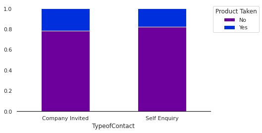

```
ProdTaken     0    1   All
CityTier
1          2670  520  3190
2           152   46   198
3          1146  354  1500
All        3968  920  4888
------------------------------------------------------------------------------------------------------------------------
```

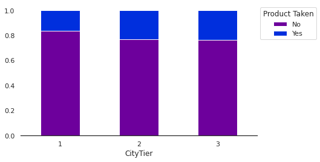

```
ProdTaken          0    1   All
Occupation
Free Lancer        0    2     2
Large Business   314  120   434
Salaried        1954  414  2368
Small Business  1700  384  2084
All             3968  920  4888
------------------------------------------------------------------------------------------------------------------------
```

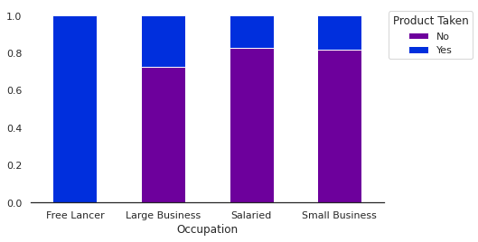

```
ProdTaken     0    1   All
Gender
Female     1630  342  1972
Male       2338  578  2916
All        3968  920  4888
------------------------------------------------------------------------------------------------------------------------
```

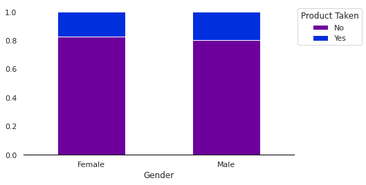

```
ProdTaken                  0    1   All
NumberOfPersonVisiting
1                         39    0    39
2                       1151  267  1418
3                       1942  460  2402
4                        833  193  1026
5                          3    0     3
All                     3968  920  4888
------------------------------------------------------------------------------------------------------------------------
```

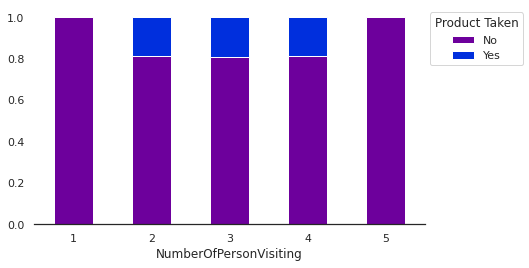

```
ProdTaken          0    1   All
ProductPitched
Basic           1290  552  1842
Deluxe          1528  204  1732
King             210   20   230
Standard         618  124   742
Super Deluxe     322   20   342
All             3968  920  4888
------------------------------------------------------------------------------------------------------------------------
```

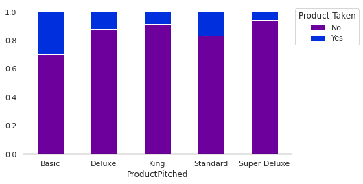

```
ProdTaken                 0    1   All
PreferredPropertyStar
3.0                    2531  488  3019
4.0                     731  182   913
5.0                     706  250   956
All                    3968  920  4888
------------------------------------------------------------------------------------------------------------------------
```

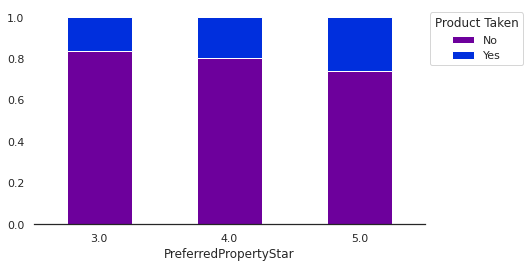

```
ProdTaken         0    1   All
NumberOfTrips
1.0             508  112   620
2.0            1186  305  1491
3.0             969  223  1192
4.0             417   61   478
5.0             396   62   458
6.0             258   64   322
7.0             156   62   218
8.0              76   29   105
19.0              0    1     1
20.0              0    1     1
21.0              1    0     1
22.0              1    0     1
All            3968  920  4888
------------------------------------------------------------------------------------------------------------------------
```

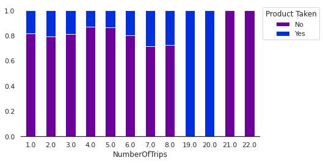

```
ProdTaken         0    1   All
MaritalStatus
Divorced        826  124   950
Married        2014  326  2340
Single          612  304   916
Unmarried       516  166   682
All            3968  920  4888
------------------------------------------------------------------------------------------------------------------------
```

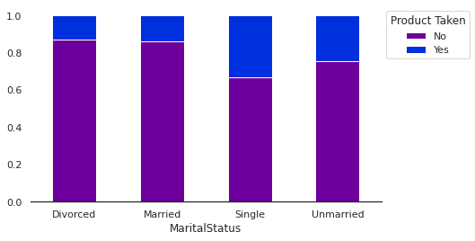

```
ProdTaken     0    1   All
Passport
0          3040  426  3466
1           928  494  1422
All        3968  920  4888
------------------------------------------------------------------------------------------------------------------------
```

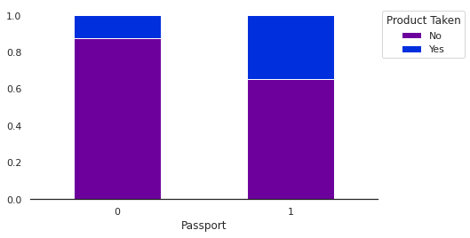

```
ProdTaken     0    1   All
OwnCar
0          1496  360  1856
1          2472  560  3032
All        3968  920  4888
------------------------------------------------------------------------------------------------------------------------
```

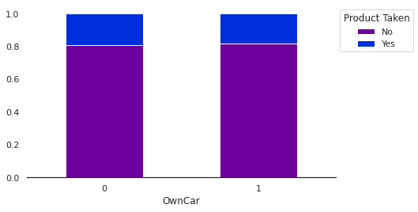

```
ProdTaken          0    1   All
Designation
AVP              322   20   342
Executive       1290  552  1842
Manager         1528  204  1732
Senior Manager   618  124   742
VP               210   20   230
All             3968  920  4888
------------------------------------------------------------------------------------------------------------------------
```

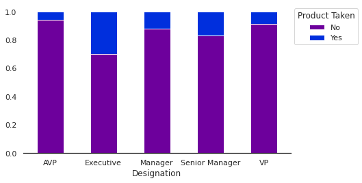

```
ProdTaken     0    1   All
Agebin
15-25       204  143   347
26-30       765  260  1025
31-40      1610  284  1894
41-50       929  144  1073
51-70       460   89   549
All        3968  920  4888
------------------------------------------------------------------------------------------------------------------------
```

[4 more figures not shown]

```python
list_columns=['TypeofContact','CityTier','Occupation','Gender','NumberOfPersonVisiting',
              'ProductPitched','PreferredPropertyStar','NumberOfTrips','MaritalStatus','Passport','OwnCar','Designation','Agebin','Incomebin','PitchSatisfactionScore','NumberOfFollowups']
for i, variable in enumerate(list_columns):
       stacked_plot(df_tour[variable])
```

### Customer profile according to product pitched and product purchased

**Basic package :**Most of the customer have Monthly income < 25000, Age is in range of 26-30, Designation as Executive belong to City tier 1, are salaried and single males . Customer contacted the company.Married customers also prefer this basic package.

**Deluxe package:** Most of the customer have Monthly income < 25000, Age is in range of 31-40, Designation as Managers belong to city tier 3 and occupation is small business and married .Customer contacted the company. City tier 1 and divorced customers also preferred this package

**King :** Most of the customer have Monthly income in range of 30000-35000, age range in 51-60, Designation as VP. Belong to city tier 1 and are single female and Occupation is small business.Females buy this package more than men.

**SuperDeluxe:** Most of the customer have Monthly income < 35000, Age is in range 41-50, Designation as AVP, belongs to tier city 3 and is Single, male and occupation is salaried. Majority of them were company invited

**Standard package:** Most of the customer have Monthly income <30000,Age is in range of 31-40 , Designation as Senior Manager, is married , from tier city 3,and occupation is small business. majority of them had self inquired.

## Outlier Detection

```python
Q1 = df_tour.quantile(0.25)             #To find the 25th percentile and 75th percentile.
Q3 = df_tour.quantile(0.75)

IQR = Q3 - Q1                           #Inter Quantile Range (75th perentile - 25th percentile)

lower=Q1-1.5*IQR                        #Finding lower and upper bounds for all values. All values outside these bounds are outliers
upper=Q3+1.5*IQR
```

```python
((df_tour.select_dtypes(include=['float64','int64'])<lower) | (df_tour.select_dtypes(include=['float64','int64'])>upper)).sum()/len(df_tour)*100
```

```
Age                        0.00000
DurationOfPitch            2.29133
NumberOfPersonVisiting     0.06137
NumberOfFollowups          6.38298
PreferredPropertyStar      0.00000
NumberOfTrips              2.22995
PitchSatisfactionScore     0.00000
NumberOfChildrenVisiting   0.00000
MonthlyIncome              7.52864
dtype: float64
```

Since customer interaction data will not be available for potential customers and new customers,outliers in Number of trips and Monthly Income needs to be handled

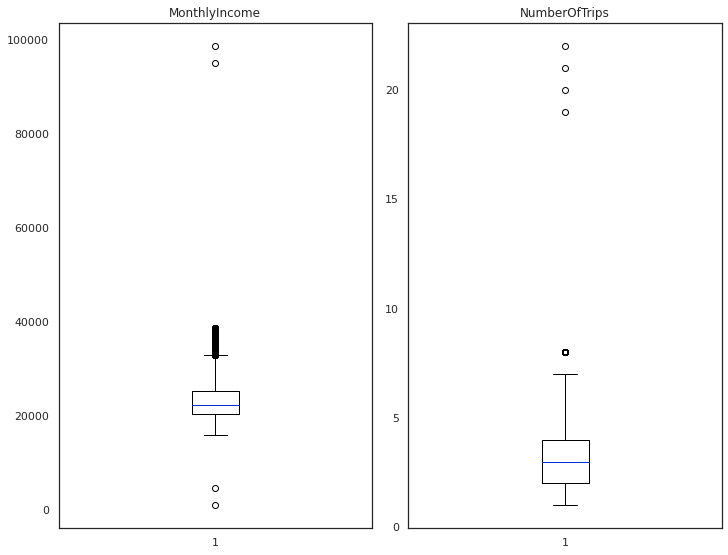

```python
numeric_columns = ['MonthlyIncome','NumberOfTrips']
# outlier detection using boxplot
plt.figure(figsize=(20,30))

for i, variable in enumerate(numeric_columns):
                     plt.subplot(4,4,i+1)
                     plt.boxplot(df_tour[variable],whis=1.5)
                     plt.tight_layout()
                     plt.title(variable)

plt.show()
```

```python
# Check MonthlyIncome extreme values
df_tour.sort_values(by=["MonthlyIncome"],ascending = False).head(5)
```

|  | ProdTaken | Age | TypeofContact | CityTier | DurationOfPitch | Occupation | Gender | NumberOfPersonVisiting | NumberOfFollowups | ProductPitched | ... | MaritalStatus | NumberOfTrips | Passport | PitchSatisfactionScore | OwnCar | NumberOfChildrenVisiting | Designation | MonthlyIncome | Agebin | Incomebin |
| --- | --- | --- | --- | --- | --- | --- | --- | --- | --- | --- | --- | --- | --- | --- | --- | --- | --- | --- | --- | --- | --- |
| 2482 | 0 | 37.00000 | Self Enquiry | 1 | 12.00000 | Salaried | Female | 3 | 5.00000 | Basic | ... | Divorced | 2.00000 | 1 | 2 | 1 | 1.00000 | Executive | 98678.00000 | 31-40 | <100000 |
| 38 | 0 | 36.00000 | Self Enquiry | 1 | 11.00000 | Salaried | Female | 2 | 4.00000 | Basic | ... | Divorced | 1.00000 | 1 | 2 | 1 | 0.00000 | Executive | 95000.00000 | 31-40 | <100000 |
| 2634 | 0 | 53.00000 | Self Enquiry | 1 | 7.00000 | Salaried | Male | 4 | 5.00000 | King | ... | Divorced | 2.00000 | 0 | 2 | 1 | 2.00000 | VP | 38677.00000 | 51-70 | <40000 |
| 4104 | 0 | 53.00000 | Self Enquiry | 1 | 7.00000 | Salaried | Male | 4 | 5.00000 | King | ... | Married | 2.00000 | 0 | 1 | 1 | 3.00000 | VP | 38677.00000 | 51-70 | <40000 |
| 3190 | 0 | 42.00000 | Company Invited | 1 | 14.00000 | Salaried | Female | 3 | 6.00000 | King | ... | Married | 3.00000 | 0 | 4 | 1 | 1.00000 | VP | 38651.00000 | 41-50 | <40000 |

5 rows × 21 columns

```python
# Check NumberOfTrips extreme values
df_tour.sort_values(by=["NumberOfTrips"],ascending = False).head(5)
```

|  | ProdTaken | Age | TypeofContact | CityTier | DurationOfPitch | Occupation | Gender | NumberOfPersonVisiting | NumberOfFollowups | ProductPitched | ... | MaritalStatus | NumberOfTrips | Passport | PitchSatisfactionScore | OwnCar | NumberOfChildrenVisiting | Designation | MonthlyIncome | Agebin | Incomebin |
| --- | --- | --- | --- | --- | --- | --- | --- | --- | --- | --- | --- | --- | --- | --- | --- | --- | --- | --- | --- | --- | --- |
| 3260 | 0 | 40.00000 | Company Invited | 1 | 16.00000 | Salaried | Male | 4 | 4.00000 | Deluxe | ... | Unmarried | 22.00000 | 0 | 2 | 1 | 1.00000 | Manager | 25460.00000 | 31-40 | <30000 |
| 816 | 0 | 39.00000 | Company Invited | 1 | 15.00000 | Salaried | Male | 3 | 3.00000 | Deluxe | ... | Unmarried | 21.00000 | 0 | 2 | 1 | 0.00000 | Manager | 21782.00000 | 31-40 | <25000 |
| 2829 | 1 | 31.00000 | Company Invited | 1 | 11.00000 | Large Business | Male | 3 | 4.00000 | Basic | ... | Single | 20.00000 | 1 | 4 | 1 | 2.00000 | Executive | 20963.00000 | 26-30 | <25000 |
| 385 | 1 | 30.00000 | Company Invited | 1 | 10.00000 | Large Business | Male | 2 | 3.00000 | Basic | ... | Single | 19.00000 | 1 | 4 | 1 | 1.00000 | Executive | 17285.00000 | 26-30 | <20000 |
| 3155 | 1 | 30.00000 | Self Enquiry | 1 | 17.00000 | Salaried | Female | 4 | 5.00000 | Basic | ... | Single | 8.00000 | 1 | 5 | 1 | 2.00000 | Executive | 21082.00000 | 26-30 | <25000 |

5 rows × 21 columns

We can see that there are just four observations with number of trips 19 or greater

```python
df_tour[(df_tour.MonthlyIncome>40000) | (df_tour.MonthlyIncome<12000)]
```

|  | ProdTaken | Age | TypeofContact | CityTier | DurationOfPitch | Occupation | Gender | NumberOfPersonVisiting | NumberOfFollowups | ProductPitched | ... | MaritalStatus | NumberOfTrips | Passport | PitchSatisfactionScore | OwnCar | NumberOfChildrenVisiting | Designation | MonthlyIncome | Agebin | Incomebin |
| --- | --- | --- | --- | --- | --- | --- | --- | --- | --- | --- | --- | --- | --- | --- | --- | --- | --- | --- | --- | --- | --- |
| 38 | 0 | 36.00000 | Self Enquiry | 1 | 11.00000 | Salaried | Female | 2 | 4.00000 | Basic | ... | Divorced | 1.00000 | 1 | 2 | 1 | 0.00000 | Executive | 95000.00000 | 31-40 | <100000 |
| 142 | 0 | 38.00000 | Self Enquiry | 1 | 9.00000 | Large Business | Female | 2 | 3.00000 | Deluxe | ... | Single | 4.00000 | 1 | 5 | 0 | 0.00000 | Manager | 1000.00000 | 31-40 | <15000 |
| 2482 | 0 | 37.00000 | Self Enquiry | 1 | 12.00000 | Salaried | Female | 3 | 5.00000 | Basic | ... | Divorced | 2.00000 | 1 | 2 | 1 | 1.00000 | Executive | 98678.00000 | 31-40 | <100000 |
| 2586 | 0 | 39.00000 | Self Enquiry | 1 | 10.00000 | Large Business | Female | 3 | 4.00000 | Deluxe | ... | Single | 5.00000 | 1 | 5 | 0 | 1.00000 | Manager | 4678.00000 | 31-40 | <15000 |

4 rows × 21 columns

**Removing these outliers form duration of pitch, monthly income, and number of trips.**

```python
#Dropping observaions with duration of pitch greater than 40. There are just 2 such observations
df_tour.drop(index=df_tour[df_tour.DurationOfPitch>37].index,inplace=True)

#Dropping observation with monthly income less than 12000 or greater than 40000. There are just 4 such observations
df_tour.drop(index=df_tour[(df_tour.MonthlyIncome>40000) | (df_tour.MonthlyIncome<12000)].index,inplace=True)

#Dropping observations with number of trips greater than 8. There are just 4 such observations
df_tour.drop(index=df_tour[df_tour.NumberOfTrips>10].index,inplace=True)
```

### Split the dataset

- Since we have a significant imbalance in the distribution of the target classes, we will use stratified sampling to ensure that relative class frequencies are approximately preserved in train and test sets.
- For that we will use the `stratify` parameter in the train_test_split function.
- Since customer interaction data will not be available for potential customers who will purchase newly introduced travel package ,so we will drop those variables from our data for modelling.

```python
df_tour.info()
```

```
<class 'pandas.core.frame.DataFrame'>
Int64Index: 4878 entries, 0 to 4887
Data columns (total 21 columns):
 #   Column                    Non-Null Count  Dtype
---  ------                    --------------  -----
 0   ProdTaken                 4878 non-null   category
 1   Age                       4878 non-null   float64
 2   TypeofContact             4878 non-null   category
 3   CityTier                  4878 non-null   category
 4   DurationOfPitch           4878 non-null   float64
 5   Occupation                4878 non-null   category
 6   Gender                    4878 non-null   category
 7   NumberOfPersonVisiting    4878 non-null   int64
 8   NumberOfFollowups         4878 non-null   float64
 9   ProductPitched            4878 non-null   category
 10  PreferredPropertyStar     4878 non-null   float64
 11  MaritalStatus             4878 non-null   category
 12  NumberOfTrips             4878 non-null   float64
 13  Passport                  4878 non-null   category
 14  PitchSatisfactionScore    4878 non-null   int64
 15  OwnCar                    4878 non-null   category
 16  NumberOfChildrenVisiting  4878 non-null   float64
 17  Designation               4878 non-null   category
 18  MonthlyIncome             4878 non-null   float64
 19  Agebin                    4878 non-null   category
 20  Incomebin                 4878 non-null   category
dtypes: category(12), float64(7), int64(2)
memory usage: 440.4 KB
```

Based on the information provided, i assume that Customer interaction data will not be available for new and potiental customers so dropping columns related to customer interaction

```python
# Separating target column
X = df_tour.drop(['ProdTaken','PitchSatisfactionScore','ProductPitched','NumberOfFollowups','DurationOfPitch','Agebin','Incomebin'],axis=1)
X = pd.get_dummies(X,drop_first=True)
y = df_tour['ProdTaken']
```

```python
# Splitting the data into train and test sets in 70:30 ratio
X_train, X_test, y_train, y_test = train_test_split(X, y, test_size=0.30, random_state=1,stratify=y)
X_train.shape, X_test.shape
```

```
((3414, 22), (1464, 22))
```

```python
def make_confusion_matrix(y_actual,y_predict,title):
    '''Plot confusion matrix'''
    fig, ax = plt.subplots(1, 1)

    cm = confusion_matrix(y_actual, y_predict, labels=[0,1])
    disp = ConfusionMatrixDisplay(confusion_matrix=cm,
                               display_labels=["No","Yes"])
    disp.plot(cmap='Greens',colorbar=True,ax=ax)

    ax.set_title(title)
    plt.tick_params(axis=u'both', which=u'both',length=0)
    plt.grid(b=None,axis='both',which='both',visible=False)
    plt.show()
```

```python
def get_metrics_score(model,X_train_df,X_test_df,y_train_pass,y_test_pass,flag=True):
    '''
    Function to calculate different metric scores of the model - Accuracy, Recall, Precision, and F1 score
    model: classifier to predict values of X
    train, test: Independent features
    train_y,test_y: Dependent variable
    threshold: thresold for classifiying the observation as 1
    flag: If the flag is set to True then only the print statements showing different will be displayed. The default value is set to True.
    roc: If the roc is set to True then only roc score will be displayed. The default value is set to False.
    '''
    # defining an empty list to store train and test results
    score_list=[]
    pred_train = model.predict(X_train_df)
    pred_test = model.predict(X_test_df)
    pred_train = np.round(pred_train)
    pred_test = np.round(pred_test)
    train_acc = accuracy_score(y_train_pass,pred_train)
    test_acc = accuracy_score(y_test_pass,pred_test)
    train_recall = recall_score(y_train_pass,pred_train)
    test_recall = recall_score(y_test_pass,pred_test)
    train_precision = precision_score(y_train_pass,pred_train)
    test_precision = precision_score(y_test_pass,pred_test)
    train_f1 = f1_score(y_train_pass,pred_train)
    test_f1 = f1_score(y_test_pass,pred_test)
    score_list.extend((train_acc,test_acc,train_recall,test_recall,train_precision,test_precision,train_f1,test_f1))
    if flag == True:
          metric_names = ['Train_Accuracy', 'Test_Accuracy', 'Train_Recall', 'Test_Recall','Train_Precision',
                          'Test_Precision', 'Train_F1-Score', 'Test_F1-Score']
          cols = ['Metric', 'Score']
          records = [(name, score) for name, score in zip(metric_names, score_list)]
          display(pd.DataFrame.from_records(records, columns=cols, index='Metric').T)
          make_confusion_matrix(y_train_pass,pred_train,"Confusion Matrix for Train")
          make_confusion_matrix(y_test_pass,pred_test,"Confusion Matrix for Test")
    return score_list # returning the list with train and test scores
```

```python
# # defining empty lists to add train and test results
acc_train = []
acc_test = []
recall_train = []
recall_test = []
precision_train = []
precision_test = []
f1_train = []
f1_test = []

def add_score_model(score):
     '''add score of modelto list'''
     acc_train.append(score[0])
     acc_test.append(score[1])
     recall_train.append(score[2])
     recall_test.append(score[3])
     precision_train.append(score[4])
     precision_test.append(score[5])
     f1_train.append(score[6])
     f1_test.append(score[7])
```

## Model Building

We'll fit Decision Tree and BaggingClassifier and Randomforest models on the train data and observe their performance.

## Decision Tree

```python
dtree=DecisionTreeClassifier(random_state=1, class_weight={0:0.20, 1:0.80})
dtree.fit(X_train,y_train)
```

```
DecisionTreeClassifier(class_weight={0: 0.2, 1: 0.8}, random_state=1)
```

| Metric | Train_Accuracy | Test_Accuracy | Train_Recall | Test_Recall | Train_Precision | Test_Precision | Train_F1-Score | Test_F1-Score |
| --- | --- | --- | --- | --- | --- | --- | --- | --- |
| Score | 1.00000 | 0.85246 | 1.00000 | 0.58696 | 1.00000 | 0.61364 | 1.00000 | 0.60000 |

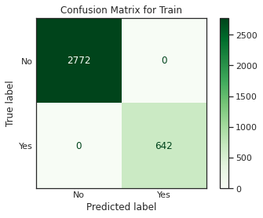

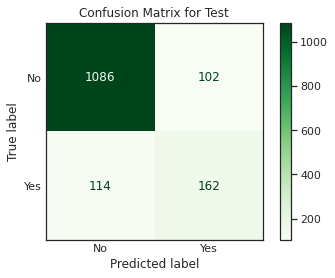

```python
dtree_score=get_metrics_score(dtree,X_train,X_test,y_train,y_test)
add_score_model(dtree_score)
```

**Observation**

Decision tree is overfitting the training data as there is lot of disparity between test and train.Recall score is also not that high

## Bagging classifier

```python
#Fitting the model
bagging_classifier = BaggingClassifier(random_state=1, verbose=1)
bagging_classifier.fit(X_train,y_train)
```

```
[Parallel(n_jobs=1)]: Using backend SequentialBackend with 1 concurrent workers.
[Parallel(n_jobs=1)]: Done   1 out of   1 | elapsed:    0.1s finished
```

```
BaggingClassifier(random_state=1, verbose=1)
```

```
[Parallel(n_jobs=1)]: Using backend SequentialBackend with 1 concurrent workers.
[Parallel(n_jobs=1)]: Done   1 out of   1 | elapsed:    0.0s finished
[Parallel(n_jobs=1)]: Using backend SequentialBackend with 1 concurrent workers.
[Parallel(n_jobs=1)]: Done   1 out of   1 | elapsed:    0.0s finished
```

| Metric | Train_Accuracy | Test_Accuracy | Train_Recall | Test_Recall | Train_Precision | Test_Precision | Train_F1-Score | Test_F1-Score |
| --- | --- | --- | --- | --- | --- | --- | --- | --- |
| Score | 0.99033 | 0.88661 | 0.95327 | 0.51087 | 0.99512 | 0.81977 | 0.97375 | 0.62946 |

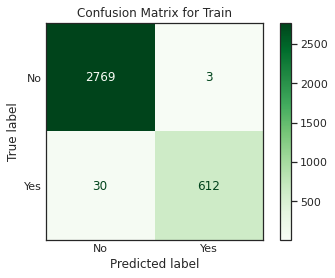

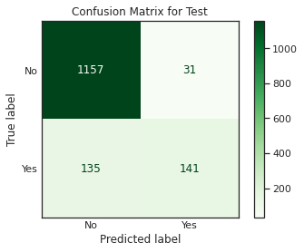

```python
bagging_score=get_metrics_score(bagging_classifier,X_train,X_test,y_train,y_test)
add_score_model(bagging_score)
```

**Observation**

Bagging is still overfitting the training data , Recall score has decreased for test data

## Random Forest

```python
rf_estimator = RandomForestClassifier(random_state=1)
rf_estimator.fit(X_train,y_train)
```

```
RandomForestClassifier(random_state=1)
```

| Metric | Train_Accuracy | Test_Accuracy | Train_Recall | Test_Recall | Train_Precision | Test_Precision | Train_F1-Score | Test_F1-Score |
| --- | --- | --- | --- | --- | --- | --- | --- | --- |
| Score | 1.00000 | 0.88730 | 1.00000 | 0.48551 | 1.00000 | 0.85350 | 1.00000 | 0.61894 |

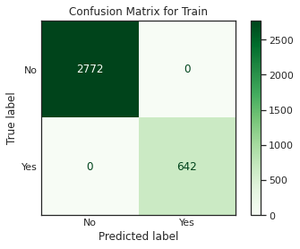

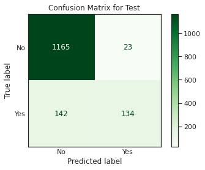

```python
score_list_rf=get_metrics_score(rf_estimator,X_train,X_test,y_train,y_test)
add_score_model(score_list_rf)
```

Random forest is also overfitting the traning data

## Model Performance Evaluation and Improvement-Bagging

```python
comparison_frame = pd.DataFrame({'Model':['Decision Tree',
                                          'Bagging Classifier',
                                          'Random Forest',
                                          ],
                                          'Train_Accuracy': acc_train,'Test_Accuracy': acc_test,
                                          'Train_Recall':recall_train,'Test_Recall':recall_test,
                                          'Train_Precision':precision_train,'Test_Precision':precision_test,
                                          'Train_F1':f1_train,
                                          'Test_F1':f1_test  })

#Sorting models in decreasing order of test recall
comparison_frame.sort_values(by='Test_Recall',ascending=False)
```

|  | Model | Train_Accuracy | Test_Accuracy | Train_Recall | Test_Recall | Train_Precision | Test_Precision | Train_F1 | Test_F1 |
| --- | --- | --- | --- | --- | --- | --- | --- | --- | --- |
| 0 | Decision Tree | 1.00000 | 0.85246 | 1.00000 | 0.58696 | 1.00000 | 0.61364 | 1.00000 | 0.60000 |
| 1 | Bagging Classifier | 0.99033 | 0.88661 | 0.95327 | 0.51087 | 0.99512 | 0.81977 | 0.97375 | 0.62946 |
| 2 | Random Forest | 1.00000 | 0.88730 | 1.00000 | 0.48551 | 1.00000 | 0.85350 | 1.00000 | 0.61894 |

## Tuning Decision Tree

```python
#Choose the type of classifier.
dtree_tuned = DecisionTreeClassifier(class_weight={0:0.20,1:0.80},random_state=1)

# Grid of parameters to choose from
parameters = {'max_depth': [1,4,7,15],
              'min_samples_leaf': [2,3,5],
              'max_leaf_nodes' : [ 5,7,10,15]

             }

# Type of scoring used to compare parameter combinations
scorer = metrics.make_scorer(metrics.recall_score)

# Run the grid search
grid_obj = GridSearchCV(dtree_tuned, parameters, scoring=scorer,n_jobs=-1)
grid_obj = grid_obj.fit(X_train, y_train)

# Set the clf to the best combination of parameters
dtree_tuned = grid_obj.best_estimator_

# Fit the best algorithm to the data.
dtree_tuned.fit(X_train, y_train)
```

```
DecisionTreeClassifier(class_weight={0: 0.2, 1: 0.8}, max_depth=7,
                       max_leaf_nodes=15, min_samples_leaf=2, random_state=1)
```

| Metric | Train_Accuracy | Test_Accuracy | Train_Recall | Test_Recall | Train_Precision | Test_Precision | Train_F1-Score | Test_F1-Score |
| --- | --- | --- | --- | --- | --- | --- | --- | --- |
| Score | 0.78559 | 0.76639 | 0.68069 | 0.66304 | 0.45332 | 0.42361 | 0.54421 | 0.51695 |

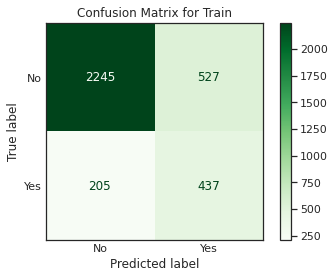

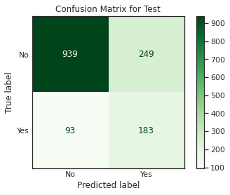

```python
score_tune_dt=get_metrics_score(dtree_tuned,X_train,X_test,y_train,y_test)
add_score_model(score_tune_dt) # add score to dataframe
```

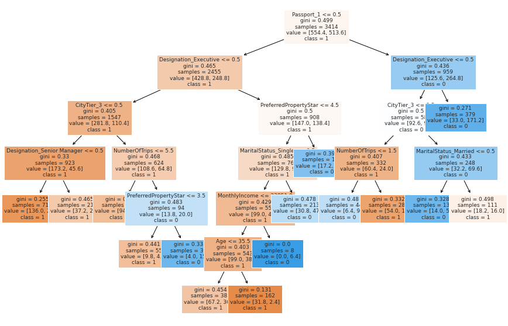

```python
plt.figure(figsize=(15,10))
feature_names = X_train.columns
out = tree.plot_tree(dtree_tuned,feature_names=feature_names,filled=True,fontsize=9,class_names=['1','0'])
for o in out:
    arrow = o.arrow_patch
    if arrow is not None:
        arrow.set_edgecolor('black')
        arrow.set_linewidth(1)
plt.show()
```

```python
feature_names = X_train.columns
importances = dtree_tuned.feature_importances_
indices = np.argsort(importances)
print (pd.DataFrame(dtree_tuned.feature_importances_, columns = ["Imp"], index = X_train.columns).sort_values(by = 'Imp', ascending = False))
```

```
                               Imp
Passport_1                 0.31385
Designation_Executive      0.23321
CityTier_3                 0.13094
PreferredPropertyStar      0.08738
MaritalStatus_Single       0.05706
NumberOfTrips              0.05188
MonthlyIncome              0.04156
MaritalStatus_Married      0.03142
Designation_Senior Manager 0.02659
Age                        0.02611
Designation_Manager        0.00000
OwnCar_1                   0.00000
MaritalStatus_Unmarried    0.00000
Occupation_Small Business  0.00000
Gender_Male                0.00000
NumberOfPersonVisiting     0.00000
Occupation_Salaried        0.00000
Occupation_Large Business  0.00000
CityTier_2                 0.00000
TypeofContact_Self Enquiry 0.00000
NumberOfChildrenVisiting   0.00000
Designation_VP             0.00000
```

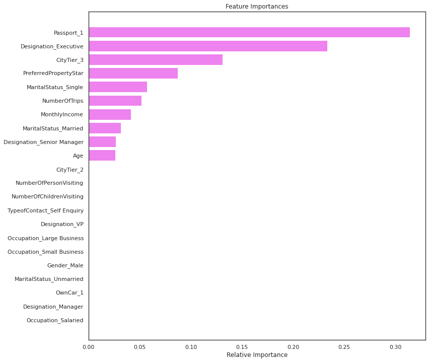

```python
plt.figure(figsize=(12,12))
plt.title('Feature Importances')
plt.barh(range(len(indices)), importances[indices], color='violet', align='center')
plt.yticks(range(len(indices)), [feature_names[i] for i in indices])
plt.xlabel('Relative Importance')
plt.show()
```

Most Important features are passport , Desgination as Executive,City tier 3.

### Tuning Random Forest

```python
# Choose the type of classifier.
rf_tuned = RandomForestClassifier(class_weight={0:0.20,1:0.80},random_state=1)

parameters = { "max_depth":[5,9,15],
               "n_estimators": [150,200,250,500],
               "min_samples_leaf": np.arange(5, 10),
                "max_features": ['auto'],
                "max_samples": np.arange(0.3,0.5, 0.7)
              }
# parameters = {"n_estimators": [50,80,150],
#               "max_depth": [1,2,3],
#               "min_samples_split": [3,4,6,7],"max_features": ['auto'],
#              }
# Type of scoring used to compare parameter combinations
scorer = metrics.make_scorer(metrics.recall_score)

# Run the grid search
grid_obj = GridSearchCV(rf_tuned, parameters, scoring=scorer,cv=5,n_jobs=-1)
grid_obj = grid_obj.fit(X_train, y_train)

# Set the clf to the best combination of parameters
rf_tuned = grid_obj.best_estimator_

# Fit the best algorithm to the data.
rf_tuned.fit(X_train, y_train)
```

```
RandomForestClassifier(class_weight={0: 0.2, 1: 0.8}, max_depth=5,
                       max_samples=0.3, min_samples_leaf=9, n_estimators=500,
                       random_state=1)
```

| Metric | Train_Accuracy | Test_Accuracy | Train_Recall | Test_Recall | Train_Precision | Test_Precision | Train_F1-Score | Test_F1-Score |
| --- | --- | --- | --- | --- | --- | --- | --- | --- |
| Score | 0.82484 | 0.81216 | 0.63707 | 0.62319 | 0.52842 | 0.50146 | 0.57768 | 0.55574 |

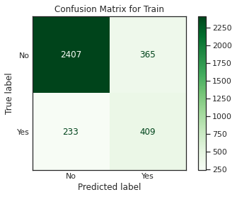

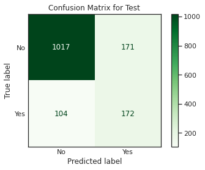

```python
score_tune_rt=get_metrics_score(rf_tuned,X_train,X_test,y_train,y_test)
add_score_model(score_tune_rt)
```

```python
feature_names = X_train.columns
importances = rf_tuned.feature_importances_
indices = np.argsort(importances)
print (pd.DataFrame(rf_tuned.feature_importances_, columns = ["Imp"], index = X_train.columns).sort_values(by = 'Imp', ascending = False))
```

```
                               Imp
Passport_1                 0.19115
MonthlyIncome              0.12971
Age                        0.12861
Designation_Executive      0.12658
MaritalStatus_Single       0.06428
CityTier_3                 0.05120
NumberOfTrips              0.04778
PreferredPropertyStar      0.04145
Designation_Manager        0.04131
MaritalStatus_Married      0.03720
NumberOfChildrenVisiting   0.01648
NumberOfPersonVisiting     0.01608
MaritalStatus_Unmarried    0.01472
Gender_Male                0.01430
TypeofContact_Self Enquiry 0.01405
Designation_Senior Manager 0.01300
Occupation_Small Business  0.01155
Occupation_Salaried        0.01133
OwnCar_1                   0.00947
Occupation_Large Business  0.00897
Designation_VP             0.00679
CityTier_2                 0.00400
```

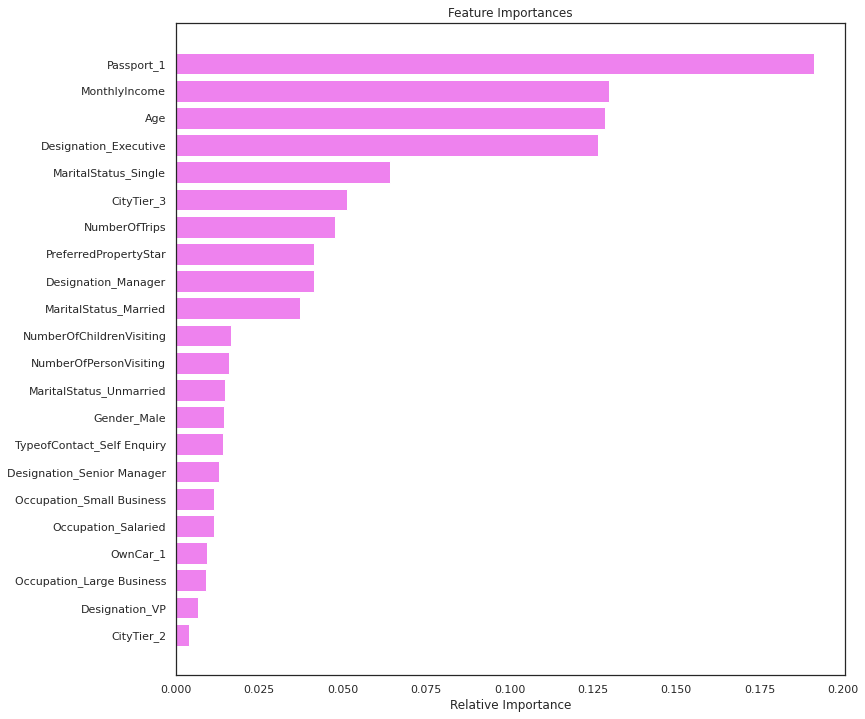

```python
plt.figure(figsize=(12,12))
plt.title('Feature Importances')
plt.barh(range(len(indices)), importances[indices], color='violet', align='center')
plt.yticks(range(len(indices)), [feature_names[i] for i in indices])
plt.xlabel('Relative Importance')
plt.show()
```

Important features are Passport,Monthly Income,Age, designation executive.

### Tuning Bagging Classifier

```python
# Choose the type of classifier.

bagging_estimator_tuned = BaggingClassifier(DecisionTreeClassifier(class_weight={0:0.20,1:0.80},random_state=1),random_state=1)

# Grid of parameters to choose from
parameters = {'max_samples': [0.7,0.8,0.9,1],
              'max_features': [0.7,0.8,0.9,1],
              'n_estimators' : [10,20,30,40,50],
             }
# Type of scoring used to compare parameter combinations
acc_scorer = metrics.make_scorer(metrics.recall_score)

# Run the grid search
grid_obj = GridSearchCV(bagging_estimator_tuned, parameters, scoring=acc_scorer,cv=5)
grid_obj = grid_obj.fit(X_train, y_train)

# Set the clf to the best combination of parameters
bagging_estimator_tuned = grid_obj.best_estimator_

# Fit the best algorithm to the data.
bagging_estimator_tuned.fit(X_train, y_train)
```

```
BaggingClassifier(base_estimator=DecisionTreeClassifier(class_weight={0: 0.2,
                                                                      1: 0.8},
                                                        random_state=1),
                  max_features=0.9, max_samples=0.9, n_estimators=30,
                  random_state=1)
```

| Metric | Train_Accuracy | Test_Accuracy | Train_Recall | Test_Recall | Train_Precision | Test_Precision | Train_F1-Score | Test_F1-Score |
| --- | --- | --- | --- | --- | --- | --- | --- | --- |
| Score | 0.99824 | 0.87910 | 0.99065 | 0.46014 | 1.00000 | 0.81935 | 0.99531 | 0.58933 |

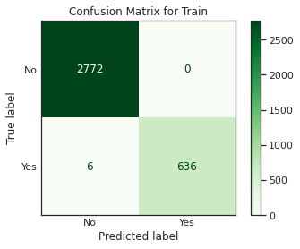

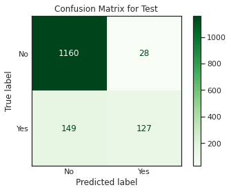

```python
bagging_tuned=get_metrics_score(bagging_estimator_tuned,X_train,X_test,y_train,y_test)
add_score_model(bagging_tuned)
```

```python
comparison_frame = pd.DataFrame({'Model':['Decision Tree',
                                          'Bagging Classifier',
                                          'Random Forest',
                                          'Tuned Decision Tree',
                                          'Tuned Random Forest',
                                          'Tuned Bagging Classifier'],
                                          'Train_Accuracy': acc_train,'Test_Accuracy': acc_test,
                                          'Train_Recall':recall_train,'Test_Recall':recall_test,
                                          'Train_Precision':precision_train,'Test_Precision':precision_test,
                                          'Train_F1':f1_train,
                                          'Test_F1':f1_test  })

#Sorting models in decreasing order of test recall
comparison_frame.sort_values(by='Test_Recall',ascending=False)
```

|  | Model | Train_Accuracy | Test_Accuracy | Train_Recall | Test_Recall | Train_Precision | Test_Precision | Train_F1 | Test_F1 |
| --- | --- | --- | --- | --- | --- | --- | --- | --- | --- |
| 3 | Tuned Decision Tree | 0.78559 | 0.76639 | 0.68069 | 0.66304 | 0.45332 | 0.42361 | 0.54421 | 0.51695 |
| 4 | Tuned Random Forest | 0.82484 | 0.81216 | 0.63707 | 0.62319 | 0.52842 | 0.50146 | 0.57768 | 0.55574 |
| 0 | Decision Tree | 1.00000 | 0.85246 | 1.00000 | 0.58696 | 1.00000 | 0.61364 | 1.00000 | 0.60000 |
| 1 | Bagging Classifier | 0.99033 | 0.88661 | 0.95327 | 0.51087 | 0.99512 | 0.81977 | 0.97375 | 0.62946 |
| 2 | Random Forest | 1.00000 | 0.88730 | 1.00000 | 0.48551 | 1.00000 | 0.85350 | 1.00000 | 0.61894 |
| 5 | Tuned Bagging Classifier | 0.99824 | 0.87910 | 0.99065 | 0.46014 | 1.00000 | 0.81935 | 0.99531 | 0.58933 |

Top

# Adaboost

```python
adaboost = AdaBoostClassifier(random_state=1)
adaboost.fit(X_train,y_train)
```

```
AdaBoostClassifier(random_state=1)
```

| Metric | Train_Accuracy | Test_Accuracy | Train_Recall | Test_Recall | Train_Precision | Test_Precision | Train_F1-Score | Test_F1-Score |
| --- | --- | --- | --- | --- | --- | --- | --- | --- |
| Score | 0.84593 | 0.84563 | 0.30374 | 0.28623 | 0.71168 | 0.73148 | 0.42576 | 0.41146 |

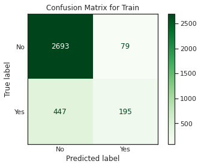

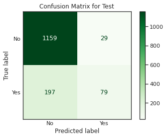

```python
adaboost_score=get_metrics_score(adaboost,X_train,X_test,y_train,y_test)
add_score_model(adaboost_score)
```

## Gradient Boost

```python
gbc = GradientBoostingClassifier(random_state=1)
gbc.fit(X_train,y_train)
```

```
GradientBoostingClassifier(random_state=1)
```

| Metric | Train_Accuracy | Test_Accuracy | Train_Recall | Test_Recall | Train_Precision | Test_Precision | Train_F1-Score | Test_F1-Score |
| --- | --- | --- | --- | --- | --- | --- | --- | --- |
| Score | 0.87961 | 0.86134 | 0.45016 | 0.38406 | 0.83285 | 0.76259 | 0.58443 | 0.51084 |

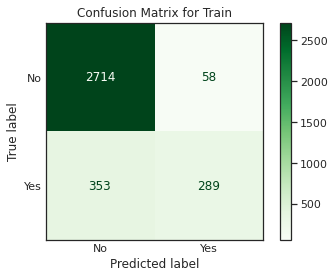

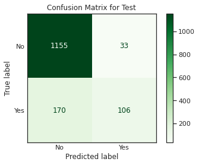

```python
gbc_score=get_metrics_score(gbc,X_train,X_test,y_train,y_test)
add_score_model(gbc_score)
```

## XGBoost

```python
xgb = XGBClassifier(random_state=1,eval_metric='logloss')
xgb.fit(X_train,y_train)
```

```
XGBClassifier(base_score=0.5, booster='gbtree', colsample_bylevel=1,
              colsample_bynode=1, colsample_bytree=1, eval_metric='logloss',
              gamma=0, gpu_id=-1, importance_type='gain',
              interaction_constraints='', learning_rate=0.300000012,
              max_delta_step=0, max_depth=6, min_child_weight=1, missing=nan,
              monotone_constraints='()', n_estimators=100, n_jobs=4,
              num_parallel_tree=1, random_state=1, reg_alpha=0, reg_lambda=1,
              scale_pos_weight=1, subsample=1, tree_method='exact',
              validate_parameters=1, verbosity=None)
```

| Metric | Train_Accuracy | Test_Accuracy | Train_Recall | Test_Recall | Train_Precision | Test_Precision | Train_F1-Score | Test_F1-Score |
| --- | --- | --- | --- | --- | --- | --- | --- | --- |
| Score | 0.99531 | 0.89003 | 0.97508 | 0.55797 | 1.00000 | 0.79793 | 0.98738 | 0.65672 |

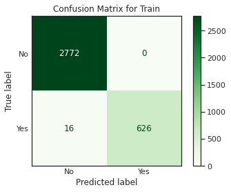

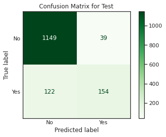

```python
xgb_score=get_metrics_score(xgb,X_train,X_test,y_train,y_test)
add_score_model(xgb_score)
```

```python
feature_names = X_train.columns
importances = xgb.feature_importances_
indices = np.argsort(importances)
print (pd.DataFrame(xgb.feature_importances_, columns = ["Imp"], index = X_train.columns).sort_values(by = 'Imp', ascending = False))
```

```
                               Imp
Designation_Executive      0.19272
Passport_1                 0.10137
CityTier_3                 0.06134
MaritalStatus_Unmarried    0.05306
MaritalStatus_Single       0.05169
TypeofContact_Self Enquiry 0.04979
Occupation_Large Business  0.04821
PreferredPropertyStar      0.04246
NumberOfTrips              0.03685
Designation_Senior Manager 0.03555
MaritalStatus_Married      0.03540
Age                        0.03488
Gender_Male                0.03235
CityTier_2                 0.03195
MonthlyIncome              0.02822
Occupation_Small Business  0.02735
NumberOfPersonVisiting     0.02626
Designation_Manager        0.02608
NumberOfChildrenVisiting   0.02314
Occupation_Salaried        0.02313
OwnCar_1                   0.02285
Designation_VP             0.01536
```

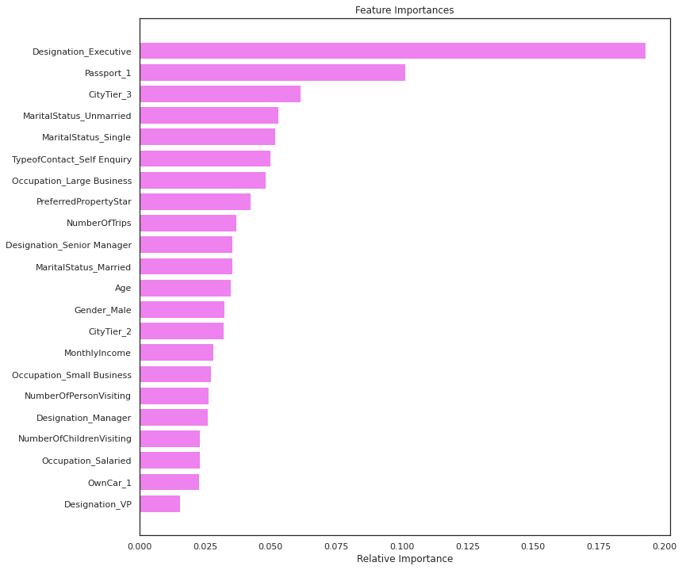

```python
plt.figure(figsize=(12,12))
plt.title('Feature Importances')
plt.barh(range(len(indices)), importances[indices], color='violet', align='center')
plt.yticks(range(len(indices)), [feature_names[i] for i in indices])
plt.xlabel('Relative Importance')
plt.show()
```